# Lab3_Assembly_Annotation

Mendel Kwan

2025-09-18

## Question 1

```
## Total length:    12756536
```

```
## Fragments:   356
```

```
## Fragments N50:   51072
```

```
## Largest frg: 302368
```

```
## Scaffolds:   0
```

```
## Mean coverage:   8
```

Since the number of base pairs in the assembly is about the same as the number of base pairs in the reference genome (12 million), we could assume a complete genome.

The coverage (8) may not be adequate. This means we have less confidence in our base calls.

## Question 2

```
## Completeness:    33.7%
```

```
## Single:      33.6%
```

```
## Duplicate:   0.1%
```

```
## Fragmented:  0.4%
```

```
## Missing: 65.8%
```

Given the poor coverage, getting one third of the genes is reasonable.

The N50 from BUSCO (51 kbp) is the same as the N50 from flye (51072 bp).

The total assembly length is 12756536 bp.

## Question 3

The duplication ratio from quast is 1.049.

According to quast there are 0 misassemblies with total length 0. This, along with the low genome fraction, suggests the reference genome does not do a good job representing the genomic diversity of the species.

## Question 4

samtools faidx ./data/GCF_000146045.2_R64_genomic.fna samtools faidx ./data/GCF_000146045.2_R64_genomic.fna NC_001133.9 > R64_chr1.fna

Note: The name was changed manually from NC_001133.9 to CHR1.

## Question 5

minimap2 -t 8 -ax asm5 ./data/R64_chr1.fna ./output/flye_output/assembly.fasta > ./output/contig_vs_chr1.sam samtools view -bS ./output/contig_vs_chr1.sam > ./output/contig_vs_chr1.bam samtools sort ./output/contig_vs_chr1.bam -o ./output/contig_vs_chr1.sorted.bam samtools index ./output/contig_vs_chr1.sorted.bam

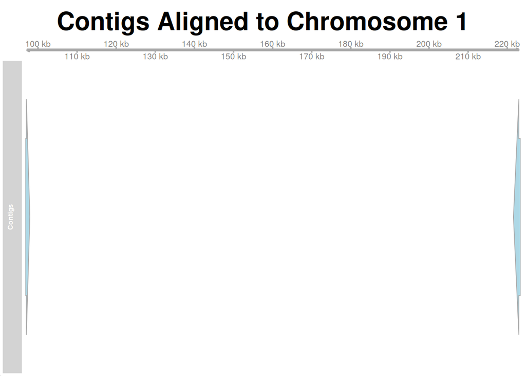

```r
bam_file ="./output/contig_vs_chr1.sorted.bam"
bam = BamFile(bam_file)
alns <- readGAlignments(bam)
gr_alns = granges(alns)
aln_track <- AnnotationTrack(gr_alns, name = "Contigs")
axis_track <- GenomeAxisTrack()
plotTracks(list(axis_track, aln_track), from = min(start(gr_alns)), to = max(end(gr_alns)), main = "Contigs Aligned to Chromosome 1")
```

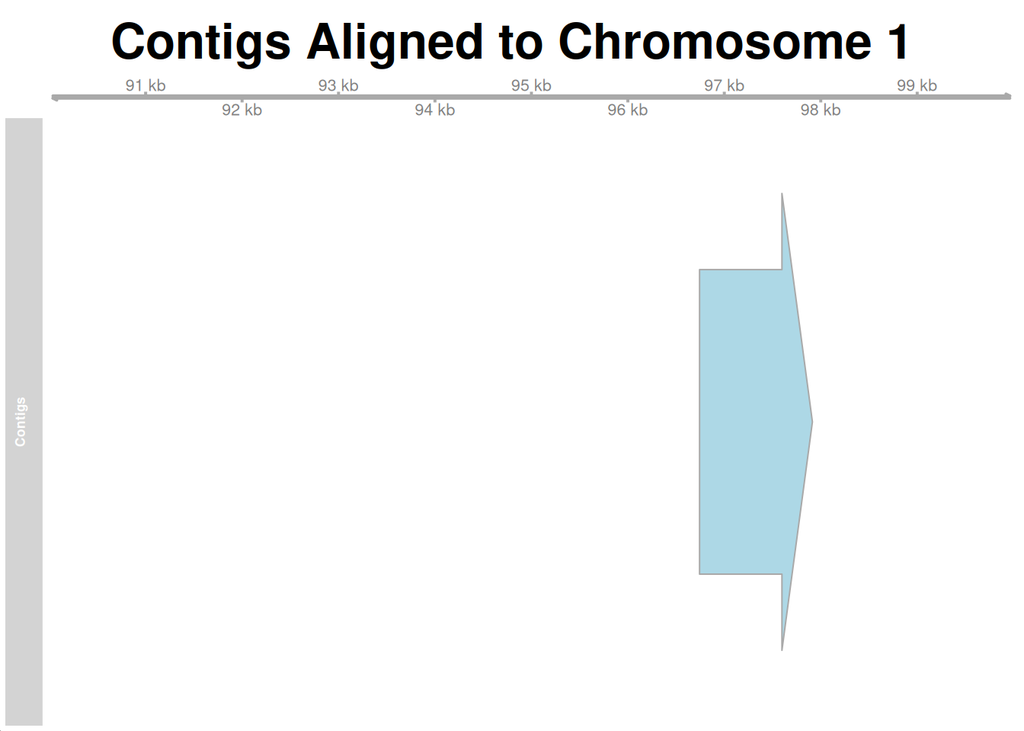

```r
plotTracks(list(axis_track, aln_track), from = 90000, to = 100000, main = "Contigs Aligned to Chromosome 1")
```

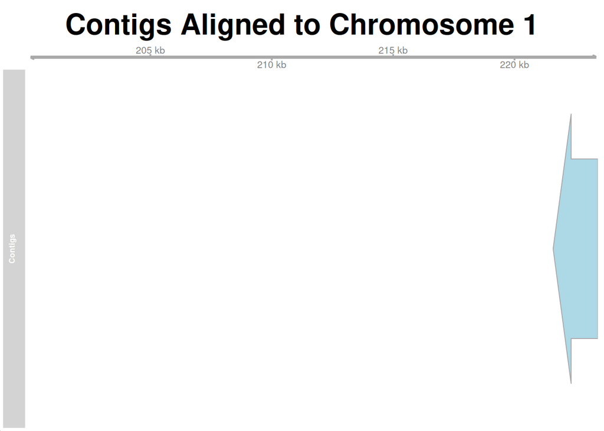

```r
plotTracks(list(axis_track, aln_track), from = 200000, to = max(end(gr_alns)), main = "Contigs Aligned to Chromosome 1")
```

There are two contigs aligned with chromosome 1.

[figure not shown]

## Question 6

cd ./output seqkit stats flye_output/assembly.fasta seqkit sort flye_output/assembly.fasta -l -r > assembly_sorted_by_length.fasta seqkit head -n 1 assembly_sorted_by_length.fasta > ./output/flye_output/longest_contig.fasta seqkit stats longest_contig.fasta

Note: The name was changed manually from contig_169 to CHR1.

Download the CDS File wget -nc https://ftp.ncbi.nlm.nih.gov/genomes/refseq/fungi/Saccharomyces_cerevisiae/latest_assembly_versions/GCF_000146045.2_R64/GCF_000146045.2_R64_cds_from_genomic.fna.gz

## Question 7

cd ./output minimap2 -ax splice -uf –secondary=no longest_contig.fasta GCF_000146045.2_R64_cds_from_genomic.fna > cds_aln.sam samtools view -bS cds_aln.sam > cds_aln.bam samtools sort cds_aln.bam -o cds_aln.sorted.bam samtools index cds_aln.sorted.bam

## Question 8

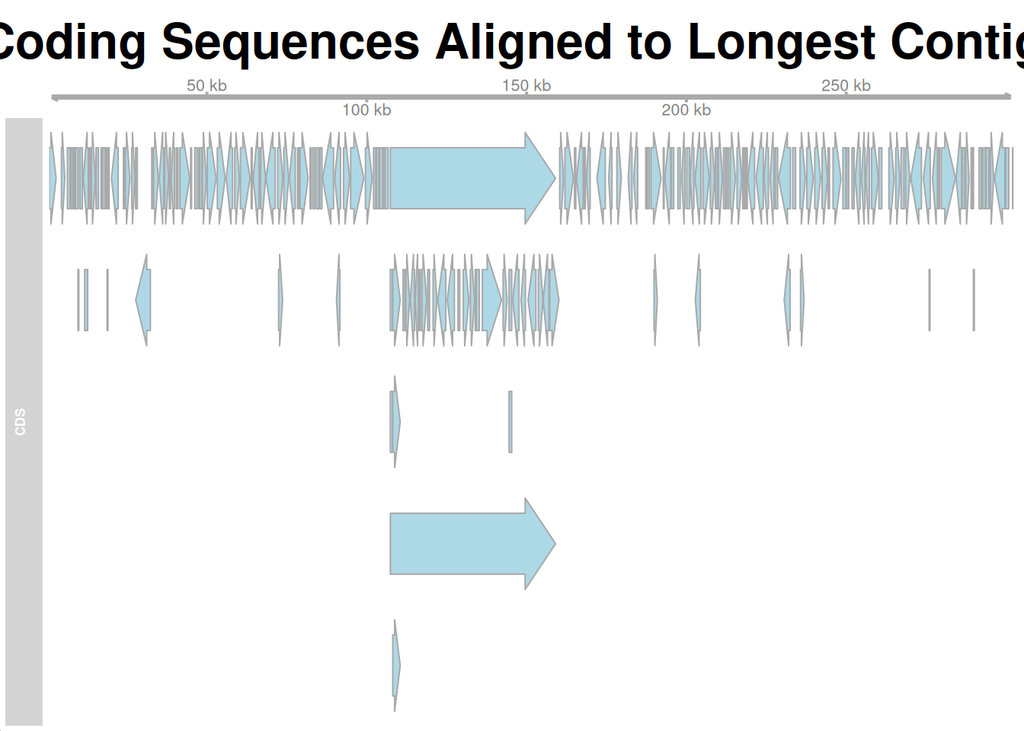

[figure not shown]

```r
bam_file ="./output/cds_aln.sorted.bam"
bam = BamFile(bam_file)
alns <- readGAlignments(bam)
gr_alns = granges(alns)
aln_track <- AnnotationTrack(gr_alns, name = "CDS")
axis_track <- GenomeAxisTrack()
plotTracks(list(axis_track, aln_track), from = min(start(gr_alns)), to = max(end(gr_alns)), main = "Coding Sequences Aligned to Longest Contig")
```